# Analyse des données d’enquête

Étude sur les métiers de la donnée dans l’enseignement supérieur et la recherche

Breton-Chauvet P., Thierry D.

04 avril 2023

[figure not shown]

# Données issues du questionnaire

## Analyse de chaque question individuellement

Variable

Stats / Values

Freqs (% of Valid)

Graph

Missing

Date de soumission  
[POSIXct, POSIXt]

1. 1980-01-01

543 (100.0%)

0  
(0.0%)

Dernière page  
[numeric]

1 distinct value

4 : 543 (100.0%)

0  
(0.0%)

Langue de départ  
[character]

1. en  
2. fr

17 ( 3.1%)  
526 (96.9%)

0  
(0.0%)

Tête de série  
[numeric]

Mean (sd) : 1046579942 (614589988)  
min < med < max:  
17668094 < 1038377027 < 2141029690  
IQR (CV) : 1048725398 (0.6)

543 distinct values

0  
(0.0%)

Dans quel type d’établissement exercez-vous votre activité ?  
[character]

1. Autre  
2. Ecole  
3. Organisme de recherche  
4. Université

32 ( 5.9%)  
29 ( 5.3%)  
286 (52.7%)  
196 (36.1%)

0  
(0.0%)

Dans quel type d’établissement exercez-vous votre activité ? [Autre]  
[character]

1. EPIC  
2. Hôpital  
3. Agence de financement de  
4. Agence nationale  
5. Agence Spatiale  
[ 21 others ]

4 (13.3%)  
2 ( 6.7%)  
1 ( 3.3%)  
1 ( 3.3%)  
1 ( 3.3%)  
21 (70.0%)

513  
(94.5%)

Où réalisez-vous votre activité en lien avec les données de recherche ? [Laboratoire / unité / équipe de recherche]  
[character]

1. Non  
2. Oui

146 (26.9%)  
397 (73.1%)

0  
(0.0%)

Où réalisez-vous votre activité en lien avec les données de recherche ? [Infrastructure de recherche]  
[character]

1. Non  
2. Oui

456 (84.0%)  
87 (16.0%)

0  
(0.0%)

Où réalisez-vous votre activité en lien avec les données de recherche ? [Service central d’appui (par exemple Direction de la recherche, DSI, SCD, …)]  
[character]

1. Non  
2. Oui

435 (80.1%)  
108 (19.9%)

0  
(0.0%)

Où réalisez-vous votre activité en lien avec les données de recherche ? [Service déconcentré d’appui (par exemple une cellule décentralisée d’une direction centrale dans une délégation ou un centre)]  
[character]

1. Non  
2. Oui

536 (98.7%)  
7 ( 1.3%)

0  
(0.0%)

Où réalisez-vous votre activité en lien avec les données de recherche ? [Direction de l’établissement (par exemple DGS, Vice-Président.e, Chargé.e de mission, …)]  
[character]

1. Non  
2. Oui

525 (96.7%)  
18 ( 3.3%)

0  
(0.0%)

Où réalisez-vous votre activité en lien avec les données de recherche ? [Autre]  
[character]

1. + domicile + terrain  
2. Agence Nationale  
3. ANR  
4. Association  
5. Association promouvant le  
[ 29 others ]

1 ( 2.9%)  
1 ( 2.9%)  
1 ( 2.9%)  
1 ( 2.9%)  
1 ( 2.9%)  
29 (85.3%)

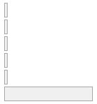

509  
(93.7%)

Sur quel domaine thématique réalisez-vous votre activité sur les données ?  
[character]

1. Sciences humaines et soci  
2. Biologie et santé  
3. Sciences du système Terre  
4. Plusieurs/tous les domain  
5. Environnement, agronomie,  
[ 7 others ]

132 (24.3%)  
83 (15.3%)  
81 (14.9%)  
79 (14.5%)  
78 (14.4%)  
90 (16.6%)

0  
(0.0%)

Sur quel domaine thématique réalisez-vous votre activité sur les données ? [Autre]  
[character]

1. bibliothèque  
2. génétique et amélioration  
3. Hydrographie, océanograph  
4. Matériaux  
5. Mécanique  
[ 9 others ]

1 ( 7.1%)  
1 ( 7.1%)  
1 ( 7.1%)  
1 ( 7.1%)  
1 ( 7.1%)  
9 (64.3%)

529  
(97.4%)

Sur quelle(s) partie(s) du cycle de vie des données intervenez-vous ? [Planification, plan de gestion de données]  
[character]

1. Non  
2. Oui

236 (43.5%)  
307 (56.5%)

0  
(0.0%)

Sur quelle(s) partie(s) du cycle de vie des données intervenez-vous ? [Collecte, création, stockage]  
[character]

1. Non  
2. Oui

136 (25.0%)  
407 (75.0%)

0  
(0.0%)

Sur quelle(s) partie(s) du cycle de vie des données intervenez-vous ? [Analyse, traitement, calcul]  
[character]

1. Non  
2. Oui

131 (24.1%)  
412 (75.9%)

0  
(0.0%)

Sur quelle(s) partie(s) du cycle de vie des données intervenez-vous ? [Préparation du dépôt (structuration et description)]  
[character]

1. Non  
2. Oui

293 (54.0%)  
250 (46.0%)

0  
(0.0%)

Sur quelle(s) partie(s) du cycle de vie des données intervenez-vous ? [Dépôt]  
[character]

1. Non  
2. Oui

305 (56.2%)  
238 (43.8%)

0  
(0.0%)

Sur quelle(s) partie(s) du cycle de vie des données intervenez-vous ? [Ouverture ou partage (accès restreint)]  
[character]

1. Non  
2. Oui

301 (55.4%)  
242 (44.6%)

0  
(0.0%)

Sur quelle(s) partie(s) du cycle de vie des données intervenez-vous ? [Réutilisation]  
[character]

1. Non  
2. Oui

330 (60.8%)  
213 (39.2%)

0  
(0.0%)

Quelles sont les activités qu’implique votre travail sur les données ? [Superviser l’ensemble du cycle de vie]  
[character]

1. Non  
2. Oui

354 (65.2%)  
189 (34.8%)

0  
(0.0%)

Quelles sont les activités qu’implique votre travail sur les données ? [Coordonner les activités de gestion et diffusion des données]  
[character]

1. Non  
2. Oui

306 (56.4%)  
237 (43.6%)

0  
(0.0%)

Quelles sont les activités qu’implique votre travail sur les données ? [Garantir la qualité des données et leur conformité de diffusion par rapport aux cadres législatifs]  
[character]

1. Non  
2. Oui

326 (60.0%)  
217 (40.0%)

0  
(0.0%)

Quelles sont les activités qu’implique votre travail sur les données ? [Décrire et mettre en œuvre le protocole d’obtention des données initiales – brutes]  
[character]

1. Non  
2. Oui

339 (62.4%)  
204 (37.6%)

0  
(0.0%)

Quelles sont les activités qu’implique votre travail sur les données ? [Nettoyer, affiner, convertir et décrire les données brutes (par des métadonnées scientifiques)]  
[character]

1. Non  
2. Oui

255 (47.0%)  
288 (53.0%)

0  
(0.0%)

Quelles sont les activités qu’implique votre travail sur les données ? [Structurer les données et les outils pour la collecte, le stockage et le traitement]  
[character]

1. Non  
2. Oui

220 (40.5%)  
323 (59.5%)

0  
(0.0%)

Quelles sont les activités qu’implique votre travail sur les données ? [Analyser, représenter, modéliser, prédire (statistiques, algorithmes, machine learning) ]  
[character]

1. Non  
2. Oui

228 (42.0%)  
315 (58.0%)

0  
(0.0%)

Quelles sont les activités qu’implique votre travail sur les données ? [Créer, structurer, décrire les jeux de données validés (ou aide à création, structuration, description)]  
[character]

1. Non  
2. Oui

262 (48.3%)  
281 (51.7%)

0  
(0.0%)

Quelles sont les activités qu’implique votre travail sur les données ? [Renseigner les métadonnées documentaires (contributeurs, établissements, licences, financeurs projets, …)]  
[character]

1. Non  
2. Oui

330 (60.8%)  
213 (39.2%)

0  
(0.0%)

Quelles sont les activités qu’implique votre travail sur les données ? [Choisir (ou aider au choix de) l’entrepôt]  
[character]

1. Non  
2. Oui

331 (61.0%)  
212 (39.0%)

0  
(0.0%)

Quelles sont les activités qu’implique votre travail sur les données ? [Déposer les jeux de données]  
[character]

1. Non  
2. Oui

334 (61.5%)  
209 (38.5%)

0  
(0.0%)

Quelles sont les activités qu’implique votre travail sur les données ? [Assurer la mise à jour des versions de jeux de données]  
[character]

1. Non  
2. Oui

428 (78.8%)  
115 (21.2%)

0  
(0.0%)

Quelles sont les activités qu’implique votre travail sur les données ? [Publier en accès ouvert ou en partage restreint]  
[character]

1. Non  
2. Oui

307 (56.5%)  
236 (43.5%)

0  
(0.0%)

Quelles sont les activités qu’implique votre travail sur les données ? [Accompagner la découverte des données]  
[character]

1. Non  
2. Oui

351 (64.6%)  
192 (35.4%)

0  
(0.0%)

Quelles sont les activités qu’implique votre travail sur les données ? [Découvrir les données]  
[character]

1. Non  
2. Oui

390 (71.8%)  
153 (28.2%)

0  
(0.0%)

Comment intervenez-vous sur ces activités ? [Garantir la qualité des données et leur conformité de diffusion par rapport aux cadres législatifs]  
[character]

1. Je coordonne  
2. Je réalise

100 (46.1%)  
117 (53.9%)

326  
(60.0%)

Comment intervenez-vous sur ces activités ? [Décrire et mettre en œuvre le protocole d’obtention des données initiales – brutes]  
[character]

1. Je coordonne  
2. Je réalise

67 (32.8%)  
137 (67.2%)

339  
(62.4%)

Comment intervenez-vous sur ces activités ? [Nettoyer, affiner, convertir et décrire les données brutes (par des métadonnées scientifiques)]  
[character]

1. Je coordonne  
2. Je réalise

74 (25.7%)  
214 (74.3%)

255  
(47.0%)

Comment intervenez-vous sur ces activités ? [Structurer les données et les outils pour la collecte, le stockage et le traitement]  
[character]

1. Je coordonne  
2. Je réalise

107 (33.1%)  
216 (66.9%)

220  
(40.5%)

Comment intervenez-vous sur ces activités ? [Analyser, représenter, modéliser, prédire (statistiques, algorithmes, machine learning) ]  
[character]

1. Je coordonne  
2. Je réalise

51 (16.2%)  
264 (83.8%)

228  
(42.0%)

Comment intervenez-vous sur ces activités ? [Créer, structurer, décrire les jeux de données validés (ou aide à création, structuration, description)]  
[character]

1. Je coordonne  
2. Je réalise

88 (31.3%)  
193 (68.7%)

262  
(48.3%)

Comment intervenez-vous sur ces activités ? [Renseigner les métadonnées documentaires (contributeurs, établissements, licences, financeurs projets, …)]  
[character]

1. Je coordonne  
2. Je réalise

73 (34.3%)  
140 (65.7%)

330  
(60.8%)

Comment intervenez-vous sur ces activités ? [Choisir (ou aider au choix de) l’entrepôt]  
[character]

1. Je coordonne  
2. Je réalise

80 (37.7%)  
132 (62.3%)

331  
(61.0%)

Comment intervenez-vous sur ces activités ? [Déposer les jeux de données]  
[character]

1. Je coordonne  
2. Je réalise

59 (28.2%)  
150 (71.8%)

334  
(61.5%)

Comment intervenez-vous sur ces activités ? [Assurer la mise à jour des versions de jeux de données]  
[character]

1. Je coordonne  
2. Je réalise

31 (27.0%)  
84 (73.0%)

428  
(78.8%)

Comment intervenez-vous sur ces activités ? [Publier en accès ouvert ou en partage restreint]  
[character]

1. Je coordonne  
2. Je réalise

76 (32.2%)  
160 (67.8%)

307  
(56.5%)

Comment intervenez-vous sur ces activités ? [Accompagner la découverte des données]  
[character]

1. Je coordonne  
2. Je réalise

73 (38.0%)  
119 (62.0%)

351  
(64.6%)

Comment intervenez-vous sur ces activités ? [Découvrir les données]  
[character]

1. Je coordonne  
2. Je réalise

45 (29.4%)  
108 (70.6%)

390  
(71.8%)

Quel est le poids de chaque activité dans votre travail ? [Superviser l’ensemble du cycle de vie]  
[character]

1. Faible  
2. Important  
3. Modéré  
4. Très important

27 (15.0%)  
53 (29.4%)  
49 (27.2%)  
51 (28.3%)

363  
(66.9%)

Quel est le poids de chaque activité dans votre travail ? [Coordonner les activités de gestion et diffusion des données]  
[character]

1. Faible  
2. Important  
3. Modéré  
4. Très important

39 (17.0%)  
71 (31.0%)  
69 (30.1%)  
50 (21.8%)

314  
(57.8%)

Quel est le poids de chaque activité dans votre travail ? [Garantir la qualité des données et leur conformité de diffusion par rapport aux cadres législatifs]  
[character]

1. Faible  
2. Important  
3. Modéré  
4. Très important

30 (14.6%)  
65 (31.7%)  
64 (31.2%)  
46 (22.4%)

338  
(62.2%)

Quel est le poids de chaque activité dans votre travail ? [Décrire et mettre en œuvre le protocole d’obtention des données initiales – brutes]  
[character]

1. Faible  
2. Important  
3. Modéré  
4. Très important

18 ( 9.4%)  
71 (37.2%)  
65 (34.0%)  
37 (19.4%)

352  
(64.8%)

Quel est le poids de chaque activité dans votre travail ? [Nettoyer, affiner, convertir et décrire les données brutes (par des métadonnées scientifiques)]  
[character]

1. Faible  
2. Important  
3. Modéré  
4. Très important

35 (12.6%)  
99 (35.7%)  
72 (26.0%)  
71 (25.6%)

266  
(49.0%)

Quel est le poids de chaque activité dans votre travail ? [Structurer les données et les outils pour la collecte, le stockage et le traitement]  
[character]

1. Faible  
2. Important  
3. Modéré  
4. Très important

35 (11.3%)  
105 (33.9%)  
83 (26.8%)  
87 (28.1%)

233  
(42.9%)

Quel est le poids de chaque activité dans votre travail ? [Analyser, représenter, modéliser, prédire (statistiques, algorithmes, machine learning) ]  
[character]

1. Faible  
2. Important  
3. Modéré  
4. Très important

18 ( 5.9%)  
100 (32.7%)  
42 (13.7%)  
146 (47.7%)

237  
(43.6%)

Quel est le poids de chaque activité dans votre travail ? [Créer, structurer, décrire les jeux de données validés (ou aide à création, structuration, description)]  
[character]

1. Faible  
2. Important  
3. Modéré  
4. Très important

38 (14.4%)  
93 (35.2%)  
78 (29.5%)  
55 (20.8%)

279  
(51.4%)

Quel est le poids de chaque activité dans votre travail ? [Renseigner les métadonnées documentaires (contributeurs, établissements, licences, financeurs projets, …)]  
[character]

1. Faible  
2. Important  
3. Modéré  
4. Très important

49 (24.6%)  
46 (23.1%)  
74 (37.2%)  
30 (15.1%)

344  
(63.4%)

Quel est le poids de chaque activité dans votre travail ? [Choisir (ou aider au choix de) l’entrepôt]  
[character]

1. Faible  
2. Important  
3. Modéré  
4. Très important

83 (41.1%)  
30 (14.9%)  
67 (33.2%)  
22 (10.9%)

341  
(62.8%)

Quel est le poids de chaque activité dans votre travail ? [Déposer les jeux de données]  
[character]

1. Faible  
2. Important  
3. Modéré  
4. Très important

74 (37.0%)  
33 (16.5%)  
73 (36.5%)  
20 (10.0%)

343  
(63.2%)

Quel est le poids de chaque activité dans votre travail ? [Assurer la mise à jour des versions de jeux de données]  
[character]

1. Faible  
2. Important  
3. Modéré  
4. Très important

41 (37.6%)  
12 (11.0%)  
39 (35.8%)  
17 (15.6%)

434  
(79.9%)

Quel est le poids de chaque activité dans votre travail ? [Publier en accès ouvert ou en partage restreint]  
[character]

1. Faible  
2. Important  
3. Modéré  
4. Très important

63 (28.3%)  
44 (19.7%)  
78 (35.0%)  
38 (17.0%)

320  
(58.9%)

Quel est le poids de chaque activité dans votre travail ? [Accompagner la découverte des données]  
[character]

1. Faible  
2. Important  
3. Modéré  
4. Très important

34 (18.9%)  
49 (27.2%)  
61 (33.9%)  
36 (20.0%)

363  
(66.9%)

Quel est le poids de chaque activité dans votre travail ? [Découvrir les données]  
[character]

1. Faible  
2. Important  
3. Modéré  
4. Très important

24 (16.7%)  
47 (32.6%)  
39 (27.1%)  
34 (23.6%)

399  
(73.5%)

Sur quels types de données travaillez-vous ? [Données de capteurs, données haut débit]  
[character]

1. Non  
2. Oui

349 (64.3%)  
194 (35.7%)

0  
(0.0%)

Sur quels types de données travaillez-vous ? [Données d’observation]  
[character]

1. Non  
2. Oui

234 (43.1%)  
309 (56.9%)

0  
(0.0%)

Sur quels types de données travaillez-vous ? [Données expérimentales]  
[character]

1. Non  
2. Oui

293 (54.0%)  
250 (46.0%)

0  
(0.0%)

Sur quels types de données travaillez-vous ? [Données de modélisation, de simulation]  
[character]

1. Non  
2. Oui

343 (63.2%)  
200 (36.8%)

0  
(0.0%)

Sur quels types de données travaillez-vous ? [Données d’enquête, statistiques…]  
[character]

1. Non  
2. Oui

324 (59.7%)  
219 (40.3%)

0  
(0.0%)

Sur quels types de données travaillez-vous ? [Données du Web (réseaux sociaux…)]  
[character]

1. Non  
2. Oui

445 (82.0%)  
98 (18.0%)

0  
(0.0%)

Sur quels types de données travaillez-vous ? [Texte (dont documents OCRisés)]  
[character]

1. Non  
2. Oui

391 (72.0%)  
152 (28.0%)

0  
(0.0%)

Sur quels types de données travaillez-vous ? [Vidéo]  
[character]

1. Non  
2. Oui

460 (84.7%)  
83 (15.3%)

0  
(0.0%)

Sur quels types de données travaillez-vous ? [Son]  
[character]

1. Non  
2. Oui

477 (87.8%)  
66 (12.2%)

0  
(0.0%)

Sur quels types de données travaillez-vous ? [Image (dont archives numérisées)]  
[character]

1. Non  
2. Oui

372 (68.5%)  
171 (31.5%)

0  
(0.0%)

Sur quels types de données travaillez-vous ? [Autre]  
[character]

1. Données personnelles  
2. Administratives  
3. archives manuscrites  
4. Archives non numérisées  
5. Articles scientifiques  
[ 43 others ]

2 ( 4.1%)  
1 ( 2.0%)  
1 ( 2.0%)  
1 ( 2.0%)  
1 ( 2.0%)  
43 (87.8%)

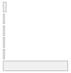

494  
(91.0%)

Quel est votre niveau de diplôme ?  
[character]

1. Bac+8  
2. Bac+5  
3. Bac+4  
4. Bac+3  
5. Bac+2  
[ 2 others ]

262 (48.3%)  
218 (40.1%)  
23 ( 4.2%)  
20 ( 3.7%)  
12 ( 2.2%)  
8 ( 1.5%)

0  
(0.0%)

Quel est votre niveau de diplôme ? [Autre]  
[character]

1. doctorat et post-docs  
2. HdR  
3. Médicin + MSc biostatisti  
4. Ph.D. (Québec)  
5. PhD  
6. PhD (USA)

1 (16.7%)  
1 (16.7%)  
1 (16.7%)  
1 (16.7%)  
1 (16.7%)  
1 (16.7%)

537  
(98.9%)

Quel est le domaine de votre formation initiale ?  
[character]

1. Sciences humaines et soci  
2. Sciences du système Terre  
3. Biologie et santé  
4. Sciences et technologies  
5. Science du numérique et m  
[ 6 others ]

132 (24.3%)  
69 (12.7%)  
66 (12.2%)  
65 (12.0%)  
62 (11.4%)  
149 (27.4%)

0  
(0.0%)

Quel est le domaine de votre formation initiale ? [Autre]  
[character]

1. Physique  
2. informatique  
3. Informatique  
4. Analyse spatiale et trait  
5. Archivistique / Informati  
[ 27 others ]

6 (15.4%)  
2 ( 5.1%)  
2 ( 5.1%)  
1 ( 2.6%)  
1 ( 2.6%)  
27 (69.2%)

504  
(92.8%)

Vous êtes-vous formé à la gestion et la diffusion des données de recherche ? [Formation diplômante]  
[character]

1. Non  
2. Oui, à l’initiative de mo  
3. Oui, à mon initiative

466 (85.8%)  
12 ( 2.2%)  
65 (12.0%)

0  
(0.0%)

Vous êtes-vous formé à la gestion et la diffusion des données de recherche ? [Formation certifiante non diplômante]  
[character]

1. Non  
2. Oui, à l’initiative de mo  
3. Oui, à mon initiative

463 (85.3%)  
13 ( 2.4%)  
67 (12.3%)

0  
(0.0%)

Vous êtes-vous formé à la gestion et la diffusion des données de recherche ? [Formation intra- ou inter-établissement (ANF, École thématique, Urfist, réseau métier…)]  
[character]

1. Non  
2. Oui, à l’initiative de mo  
3. Oui, à mon initiative

313 (57.6%)  
43 ( 7.9%)  
187 (34.4%)

0  
(0.0%)

Vous êtes-vous formé à la gestion et la diffusion des données de recherche ? [Autoformation]  
[character]

1. Non  
2. Oui, à l’initiative de mo  
3. Oui, à mon initiative

105 (19.3%)  
20 ( 3.7%)  
418 (77.0%)

0  
(0.0%)

Quels postes, fonctions ou responsabilités significatifs avez-vous occupés dans l’enseignement supérieur et/ou la recherche, du plus récent au plus ancien ? [Intitulé du poste le plus récent]  
[character]

1. Doctorant  
2. Ingénieur de recherche  
3. Chercheur  
4. Maitre de conférences  
5. Chargé de recherche  
[ 426 others ]

10 ( 2.0%)  
8 ( 1.6%)  
5 ( 1.0%)  
5 ( 1.0%)  
4 ( 0.8%)  
460 (93.5%)

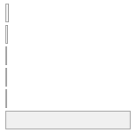

51  
(9.4%)

Quels postes, fonctions ou responsabilités significatifs avez-vous occupés dans l’enseignement supérieur et/ou la recherche, du plus récent au plus ancien ? [Intitulé du poste précédent]…86  
[character]

1. Doctorant  
2. Chercheur  
3. ATER  
4. Ingénieur de recherche  
5. Assistant de recherche  
[ 322 others ]

12 ( 3.3%)  
6 ( 1.6%)  
4 ( 1.1%)  
4 ( 1.1%)  
3 ( 0.8%)  
336 (92.1%)

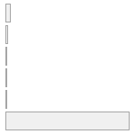

178  
(32.8%)

Quels postes, fonctions ou responsabilités significatifs avez-vous occupés dans l’enseignement supérieur et/ou la recherche, du plus récent au plus ancien ? [Intitulé du poste précédent]…87  
[character]

1. Doctorant  
2. ATER  
3. Chargé de recherche  
4. doctorante  
5. Doctorante  
[ 139 others ]

7 ( 4.4%)  
4 ( 2.5%)  
2 ( 1.3%)  
2 ( 1.3%)  
2 ( 1.3%)  
141 (89.2%)

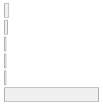

385  
(70.9%)

Quels postes, fonctions ou responsabilités significatifs avez-vous occupés dans l’enseignement supérieur et/ou la recherche, du plus récent au plus ancien ? [Intitulé du poste précédent]…88  
[character]

1. Doctorant  
2. ATER  
3. aaaaaaaa  
4. AI d’exploitation d’instr  
5. assegno di ricerca (assis  
[ 57 others ]

5 ( 7.5%)  
2 ( 3.0%)  
1 ( 1.5%)  
1 ( 1.5%)  
1 ( 1.5%)  
57 (85.1%)

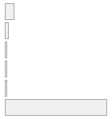

476  
(87.7%)

Quels postes, fonctions ou responsabilités significatifs avez-vous occupés dans l’enseignement supérieur et/ou la recherche, du plus récent au plus ancien ? [Intitulé du poste précédent]…89  
[character]

1. Doctorant  
2. agronomic engineer, GIS d  
3. Bibliothécaire  
4. CEO  
5. Cheffe de service (inform  
[ 21 others ]

2 ( 7.4%)  
1 ( 3.7%)  
1 ( 3.7%)  
1 ( 3.7%)  
1 ( 3.7%)  
21 (77.8%)

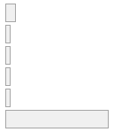

516  
(95.0%)

Quelle est votre catégorie d’emploi actuel ?  
[character]

1. Chercheur / Enseignant-ch  
2. Personnel d’appui / souti

230 (42.4%)  
313 (57.6%)

0  
(0.0%)

Précisez votre catégorie…91  
[character]

1. Doctorant(e) / Post-docto  
2. Maître de Conférences / C  
3. Professeur(e) / Directeur

57 (24.8%)  
89 (38.7%)  
84 (36.5%)

313  
(57.6%)

Précisez votre catégorie…92  
[character]

1. Catégorie A  
2. Catégorie B  
3. Catégorie C

280 (89.5%)  
28 ( 8.9%)  
5 ( 1.6%)

230  
(42.4%)

Précisez votre branche d’activité.  
[character]

1. Autre  
2. Gestion et pilotage, Part  
3. Information, Documentatio  
4. Informatique, Statistique  
5. Personnels des bibliothèq  
6. Sciences humaines et soci

45 (14.4%)  
16 ( 5.1%)  
50 (16.0%)  
100 (31.9%)  
36 (11.5%)  
66 (21.1%)

230  
(42.4%)

Précisez votre branche d’activité. [Autre]  
[character]

1. BAP A  
2. Biologie  
3. instrumentation  
4. A  
5. analyse  
[ 33 others ]

2 ( 4.9%)  
2 ( 4.9%)  
2 ( 4.9%)  
1 ( 2.4%)  
1 ( 2.4%)  
33 (80.5%)

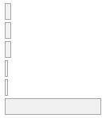

502  
(92.4%)

Dans le cadre de votre activité sur les données, sur quels réseaux ou communautés vous appuyez-vous ?  
[character]

1. infrastructure de recherc  
2. Réseau de mon établisseme  
3. réseau de l’établissement  
4. Aucun  
5. réseau de mon établisseme  
[ 365 others ]

9 ( 2.2%)  
6 ( 1.5%)  
5 ( 1.2%)  
4 ( 1.0%)  
4 ( 1.0%)  
377 (93.1%)

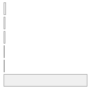

138  
(25.4%)

Sur quelles activités auriez-vous besoin d’une formation ? [Superviser l’ensemble du cycle de vie]  
[character]

1. Non  
2. Oui

412 (75.9%)  
131 (24.1%)

0  
(0.0%)

Sur quelles activités auriez-vous besoin d’une formation ? [Coordonner les activités de gestion et diffusion des données]  
[character]

1. Non  
2. Oui

418 (77.0%)  
125 (23.0%)

0  
(0.0%)

Sur quelles activités auriez-vous besoin d’une formation ? [Garantir la qualité des données et leur conformité de diffusion par rapport aux cadres législatifs]  
[character]

1. Non  
2. Oui

344 (63.4%)  
199 (36.6%)

0  
(0.0%)

Sur quelles activités auriez-vous besoin d’une formation ? [Décrire et mettre en œuvre le protocole d’obtention des données initiales – brutes]  
[character]

1. Non  
2. Oui

472 (86.9%)  
71 (13.1%)

0  
(0.0%)

Sur quelles activités auriez-vous besoin d’une formation ? [Nettoyer, affiner, convertir et décrire les données brutes (par des métadonnées scientifiques)]  
[character]

1. Non  
2. Oui

450 (82.9%)  
93 (17.1%)

0  
(0.0%)

Sur quelles activités auriez-vous besoin d’une formation ? [Structurer les données et les outils pour la collecte, le stockage et le traitement]  
[character]

1. Non  
2. Oui

422 (77.7%)  
121 (22.3%)

0  
(0.0%)

Sur quelles activités auriez-vous besoin d’une formation ? [Analyser, représenter, modéliser, prédire (statistiques, algorithmes, machine learning) ]  
[character]

1. Non  
2. Oui

410 (75.5%)  
133 (24.5%)

0  
(0.0%)

Sur quelles activités auriez-vous besoin d’une formation ? [Créer, structurer, décrire les jeux de données validés (ou aide à création, structuration, description)]  
[character]

1. Non  
2. Oui

444 (81.8%)  
99 (18.2%)

0  
(0.0%)

Sur quelles activités auriez-vous besoin d’une formation ? [Renseigner les métadonnées documentaires (contributeurs, établissements, licences, financeurs projets, …)]  
[character]

1. Non  
2. Oui

432 (79.6%)  
111 (20.4%)

0  
(0.0%)

Sur quelles activités auriez-vous besoin d’une formation ? [Choisir (ou aider au choix de) l’entrepôt]  
[character]

1. Non  
2. Oui

421 (77.5%)  
122 (22.5%)

0  
(0.0%)

Sur quelles activités auriez-vous besoin d’une formation ? [Déposer les jeux de données]  
[character]

1. Non  
2. Oui

445 (82.0%)  
98 (18.0%)

0  
(0.0%)

Sur quelles activités auriez-vous besoin d’une formation ? [Assurer la mise à jour des versions de jeux de données]  
[character]

1. Non  
2. Oui

451 (83.1%)  
92 (16.9%)

0  
(0.0%)

Sur quelles activités auriez-vous besoin d’une formation ? [Publier en accès ouvert ou en partage restreint]  
[character]

1. Non  
2. Oui

442 (81.4%)  
101 (18.6%)

0  
(0.0%)

Sur quelles activités auriez-vous besoin d’une formation ? [Faire un état des lieux des données existantes, des vocabulaires, standards et infrastructures…]  
[character]

1. Non  
2. Oui

368 (67.8%)  
175 (32.2%)

0  
(0.0%)

Sur quelles activités auriez-vous besoin d’une formation ? [Autre]  
[character]

1. Accompagnement au cas par  
2. Accompagnement aux donnée  
3. aide juridique sur les li  
4. aspects juridiques  
5. Aucun, ce n’est pas mon m  
[ 34 others ]

1 ( 2.6%)  
1 ( 2.6%)  
1 ( 2.6%)  
1 ( 2.6%)  
1 ( 2.6%)  
34 (87.2%)

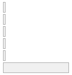

504  
(92.8%)

Sous quel intitulé présentez-vous votre poste actuel ?  
[character]

1. Chercheur  
2. Doctorant  
3. enseignant-chercheur  
4. enseignant chercheur  
5. Enseignant-chercheur  
[ 490 others ]

5 ( 0.9%)  
5 ( 0.9%)  
5 ( 0.9%)  
4 ( 0.7%)  
4 ( 0.7%)  
518 (95.7%)

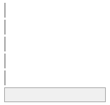

2  
(0.4%)

Votre établissement/organisme a-t-il formalisé une organisation des activités ou des rôles sur les données à l’échelle de l’établissement ou de différentes structures ?  
[character]

1. Non  
2. Oui

143 (42.2%)  
196 (57.8%)

204  
(37.6%)

Vous pouvez décrire ici les éléments relatifs à cette formalisation, fournir un lien ou indiquer toute autre information.  
[character]

1. - equipe de 4 personnes c  
2. - FAIR  
3. Administrateur des donnée  
4. atelier de la donnée  
5. Atelier de la Donnée  
[ 119 others ]

1 ( 0.8%)  
1 ( 0.8%)  
1 ( 0.8%)  
1 ( 0.8%)  
1 ( 0.8%)  
119 (96.0%)

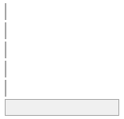

419  
(77.2%)

Accepteriez-vous un entretien pour approfondir cette enquête ? Nous souhaitons approfondir cette enquête au travers d’entretiens avec des profils variés de professionnels des données de recherche. Si vous êtes volontaire pour un entretien en visio dans les prochains mois, merci de laisser vos coordonnées pour que nous puissions vous recontacter. [Prénom]  
[character]

1. Caroline  
2. Guillaume  
3. Julien  
4. Pierre  
5. Anne  
[ 151 others ]

3 ( 1.6%)  
3 ( 1.6%)  
3 ( 1.6%)  
3 ( 1.6%)  
2 ( 1.1%)  
169 (92.3%)

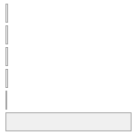

360  
(66.3%)

Accepteriez-vous un entretien pour approfondir cette enquête ? Nous souhaitons approfondir cette enquête au travers d’entretiens avec des profils variés de professionnels des données de recherche. Si vous êtes volontaire pour un entretien en visio dans les prochains mois, merci de laisser vos coordonnées pour que nous puissions vous recontacter. [Nom]  
[character]

1. Gay  
2. Aboudarham  
3. Aguirrebengoa  
4. almuhisen  
5. Antolinos-Basso  
[ 177 others ]

2 ( 1.1%)  
1 ( 0.5%)  
1 ( 0.5%)  
1 ( 0.5%)  
1 ( 0.5%)  
177 (96.7%)

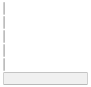

360  
(66.3%)

Accepteriez-vous un entretien pour approfondir cette enquête ? Nous souhaitons approfondir cette enquête au travers d’entretiens avec des profils variés de professionnels des données de recherche. Si vous êtes volontaire pour un entretien en visio dans les prochains mois, merci de laisser vos coordonnées pour que nous puissions vous recontacter. [Adresse électronique]  
[character]  
Emails

Valid  
Invalid  
Duplicates

182 (98.9%)  
2 ( 1.1%)  
0 ( 0.0%)

359  
(66.1%)

Accepteriez-vous un entretien pour approfondir cette enquête ? Nous souhaitons approfondir cette enquête au travers d’entretiens avec des profils variés de professionnels des données de recherche. Si vous êtes volontaire pour un entretien en visio dans les prochains mois, merci de laisser vos coordonnées pour que nous puissions vous recontacter. [Téléphone]  
[character]

1. /  
2. +229 66263534  
3. +256772473243  
4. +33(0)658485906  
5. +33607158091  
[ 120 others ]

1 ( 0.8%)  
1 ( 0.8%)  
1 ( 0.8%)  
1 ( 0.8%)  
1 ( 0.8%)  
120 (96.0%)

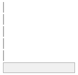

418  
(77.0%)